# TidyBiology Final Project: Identifying top gene promoters of brain metastasis

Anna Towne

2023-11-06

Three (3) RNA sequencing datasets have been identified which each compare the transcriptome of a parental cancer cell line and its brain metastatic (BrM) derivative. By combining these three individual comparisons across their three distinct cell lines, we may identify gene candidates which play a role in promoting brain metastasis (theoretically) regardless of primary tumor type.

### Import RNA sequencing data from the NCBI Gene Expression Omnibus (GEO)

We first retrieve three RNA sequencing datasets from the GEO for non-small cell lung cancer lines PC9 and H2030 as well as the breast cancer line CN34. Code for data retrieval and calculations (log2FC and pvalue) are adapted from that provided by GEO2R per dataset (https://www.ncbi.nlm.nih.gov/geo/geo2r/).

Below are (truncated) matrices representing each imported GEO dataset which has been tidied prior to further analysis. Also shown are volcano plots for each dataset.

```
##          ID       Symbol log2FoldChange        pvalue
## 1      3897        L1CAM      -5.435374 1.470279e-140
## 2    283120          H19      -7.398270 6.778584e-106
## 3 102724852 LOC102724852      -7.436995 3.625336e-102
## 4      3977         LIFR       4.747745 2.492138e-100
## 5      3488       IGFBP5      -5.881594  1.947265e-94
```

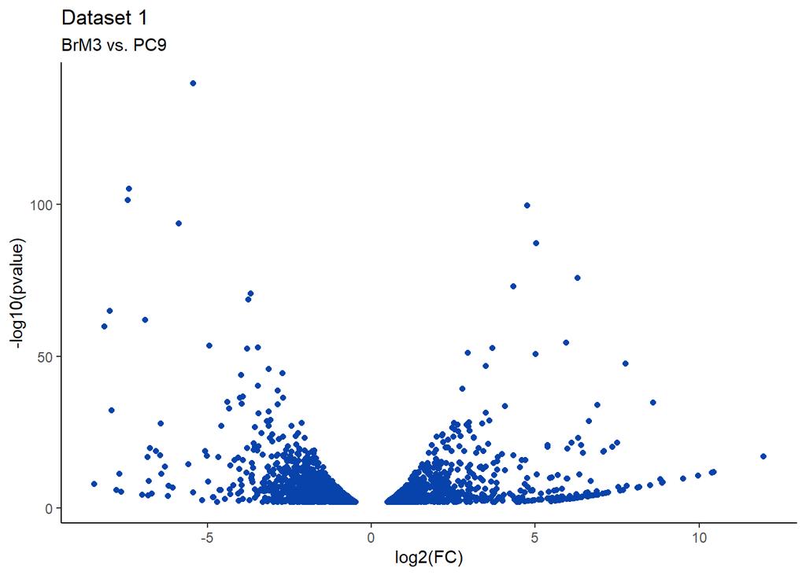

```
##                      ID Symbol log2FoldChange       pvalue
## 212977_at     212977_at  ACKR3       8.016583 3.929711e-06
## 216238_s_at 216238_s_at    FGB       9.034580 4.073461e-06
## 201163_s_at 201163_s_at IGFBP7      10.889064 6.168498e-06
## 209488_s_at 209488_s_at  RBPMS       7.627535 8.616759e-06
## 205650_s_at 205650_s_at    FGA       6.416275 1.070682e-05
```

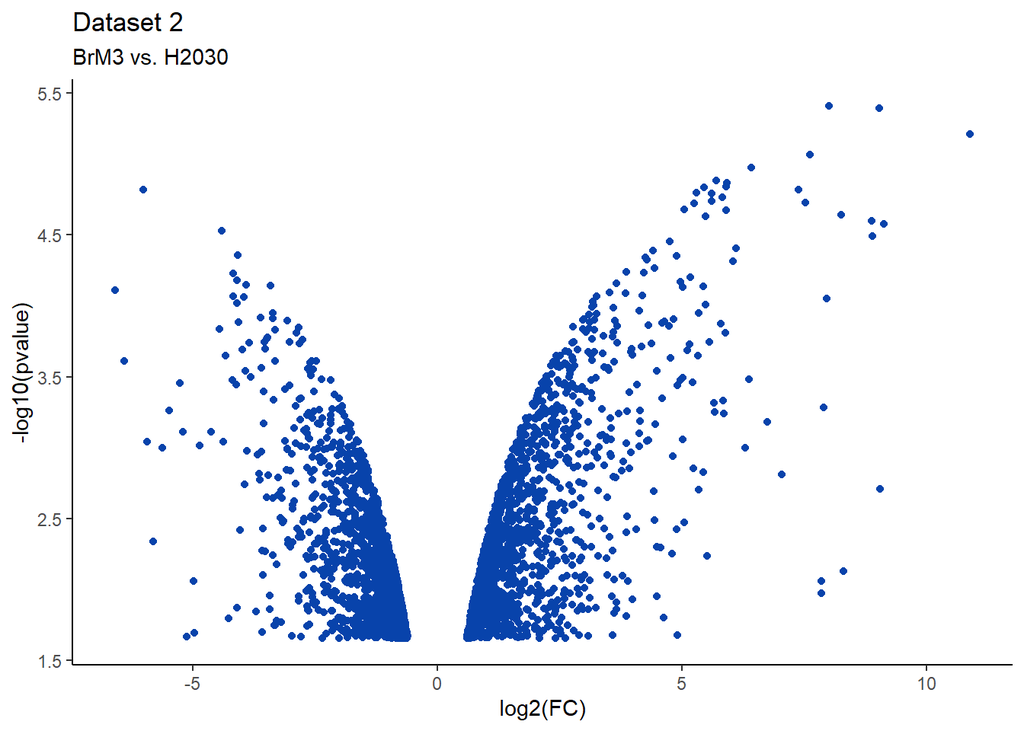

```
##                  ID Symbol log2FoldChange       pvalue
## 206224_at 206224_at   CST1      -5.845574 1.182072e-05
## 209173_at 209173_at   AGR2      -6.940470 1.391401e-05
## 205534_at 205534_at  PCDH7      -5.108525 3.368149e-05
## 213194_at 213194_at  ROBO1      -5.772783 5.601701e-05
## 204078_at 204078_at   P3H4      -3.841142 6.999689e-05
```

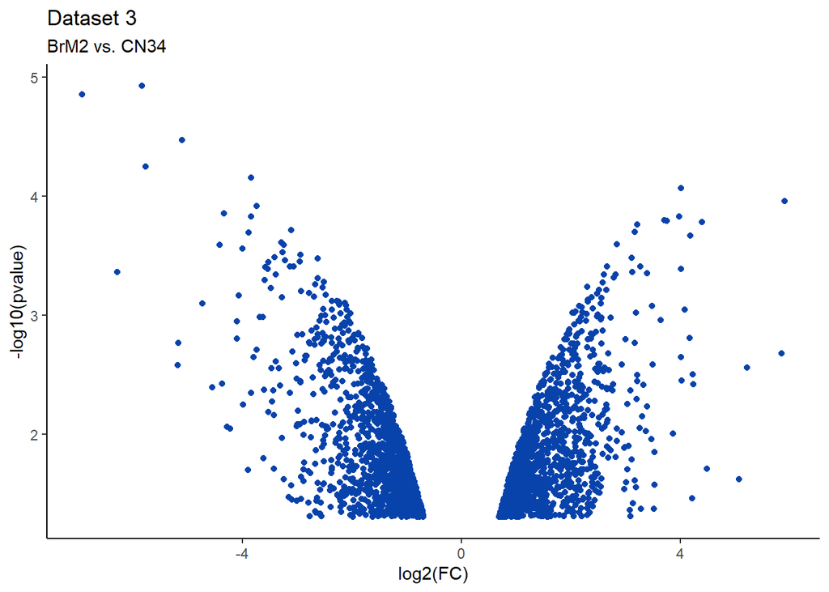

### Join dataset matrices by their gene symbols

Below is a representative portion of the matrix of combined data from all three imported GEO datasets. The genes have been ordered by descending average log2FC and genes without reported values for one or more datasets are excluded.

```
##     Symbol log2FC_1     pvalue_1 log2FC_2     pvalue_2   log2FC_3     pvalue_3
## 1   COL8A1 5.987537 2.611527e-20 4.292977 8.980307e-04  1.4975417 0.0210315693
## 2    ACKR3 1.527468 2.751641e-05 8.016583 3.929711e-06  1.1627451 0.0250964637
## 3     BMP2 8.117860 1.955215e-07 3.974862 2.019925e-04 -2.1197842 0.0108900222
## 4  SLC16A7 7.347140 7.093500e-21 3.473589 7.905588e-03 -0.9245425 0.0339306451
## 5  SLC16A7 7.347140 7.093500e-21 2.756300 5.814594e-03 -0.9245425 0.0339306451
## 6     BMP2 8.117860 1.955215e-07 2.952343 5.961793e-03 -2.1197842 0.0108900222
## 7    PROCR 1.276779 1.614204e-05 8.309268 7.397847e-03 -0.7178736 0.0469139029
## 8  SLC16A7 7.347140 7.093500e-21 3.473589 7.905588e-03 -2.0207987 0.0168740132
## 9     BMP2 8.117860 1.955215e-07 3.974862 2.019925e-04 -3.8451593 0.0001482655
## 10 SLC16A7 7.347140 7.093500e-21 2.756300 5.814594e-03 -2.0207987 0.0168740132
##    sum_log2FC aver_log2FC
## 1   11.778056    3.926019
## 2   10.706796    3.568932
## 3    9.972938    3.324313
## 4    9.896187    3.298729
## 5    9.178898    3.059633
## 6    8.950419    2.983473
## 7    8.868173    2.956058
## 8    8.799931    2.933310
## 9    8.247563    2.749188
## 10   8.082642    2.694214
```

### Identify top gene hits (most upregulated, most downregulated)

The below tables report the 10 most upregulated and the 10 most downregulated genes from the combined data frame.

```
##     Symbol aver_log2FC
## 1   COL8A1    3.926019
## 2    ACKR3    3.568932
## 3     BMP2    3.324313
## 4  SLC16A7    3.298729
## 5  SLC16A7    3.059633
## 6     BMP2    2.983473
## 7    PROCR    2.956058
## 8  SLC16A7    2.933310
## 9     BMP2    2.749188
## 10 SLC16A7    2.694214
```

```
##     Symbol aver_log2FC
## 265  PCDH7   -1.863654
## 266  PCDH7   -1.889639
## 267  PCDH7   -1.896327
## 268  PCDH7   -2.225868
## 269   SOBP   -2.253262
## 270  PCDH7   -2.390799
## 271 IGFBP5   -2.464053
## 272  CRIP2   -2.533709
## 273 IGFBP5   -2.541260
## 274  TNNC1   -3.015044
```

### Plot average log2FC values from combined datasets

I am interested in observing the distribution of genes based on their transcriptional dysregulation in brain metastatic cell lines. I will plot average log2FC values on a violin plot, highlighting the top & bottom 10 hits.

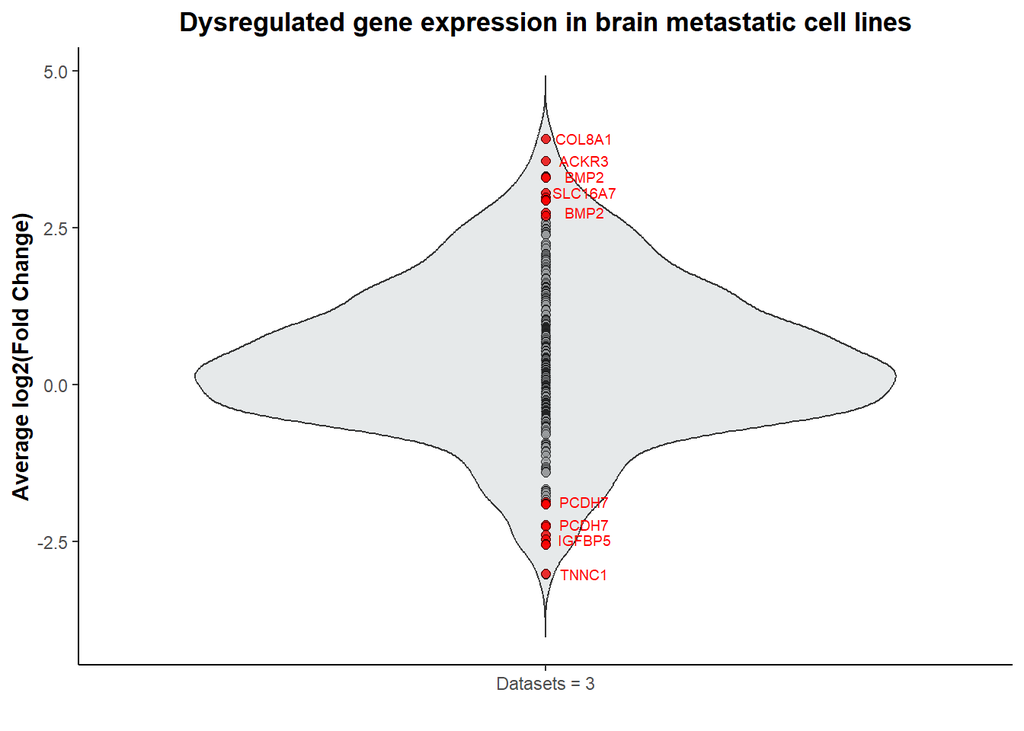

### Future directions

Follow-up of this study would entail identifying upregulated gene hits which are both therapeutically targetable and remain largely unexplored in the context of brain metastasis. For example, while previous literature links ACKR3 to both metastasis and brain cancer, the role of ACKR3 in promoting brain metastasis may yet be understudied. Further, a “potent, selective, [and] orally available” ACKR3 antagonist was discovered in 2020 (Richard-Bildstein et al.), lending further investigation of the impact of ACKR3 inhibition on cell migration and cranial infiltration through combined in vitro and in vivo studies.

### Acknowledgements

I would like to acknowledge Hoj et al., Nguyen et al., and Bos et al. for disseminating their RNA sequencing results through the GEO, as well as our wonderful course professor and instructors for providing an informative class.